# Activity Type Prediction

Conrad Yoder

February 11, 2018

## Loading, Exploratory Data Analysis

Assume the data has already been downloaded from the website metioned in the assignment.

```r
pmltrain <- read.csv("pml-training.csv")
pmltest <- read.csv("pml-testing.csv")
dim(pmltrain)
```

```
## [1] 19622   160
```

```r
dim(pmltest)
```

```
## [1]  20 160
```

We examine the data (not printed due to large amount of output):

```r
str(pmltrain)
str(pmltest)
head(pmltrain)
head(pmltest)
```

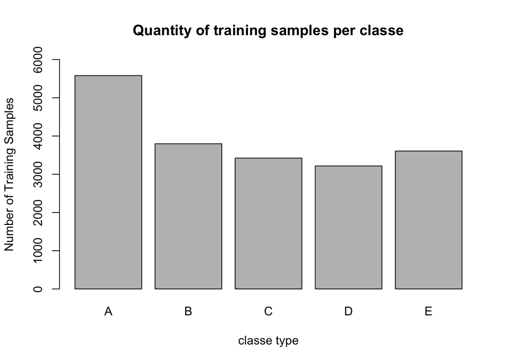

```r
plot(pmltrain$classe, main = "Quantity of training samples per classe",
     xlab = "classe type", ylab = "Number of Training Samples", ylim = c(0, 6000))
```

Digging into the data, we notice:

- Along with **NA**s for missing data, there are blank values, and the string `#DIV/0!`
- Quite a few columns (*e.g.* **kurtosis_yaw_belt**, **skewness_roll_belt**) contain little or no data
- The first 7 columns appear to not contain relevant data for predicting outcome (*e.g.*, column number, username, various timestamps)

## Cleaning Data

We reload the data and remove columns we don’t want, as per the observations noted above:

```r
pmltrain <- read.csv("pml-training.csv", na.strings = c("NA", "#DIV/0!", ""))
pmltest <- read.csv("pml-testing.csv", na.strings = c("NA", "#DIV/0!", ""))
pmltrain <- pmltrain[, -c(1:7)]
pmltest <- pmltest[, -c(1:7)]
pmltrain <- pmltrain[, colSums(is.na(pmltrain)) == 0]
pmltest <- pmltest[, colSums(is.na(pmltest)) == 0]
dim(pmltrain)
```

```
## [1] 19622    53
```

```r
dim(pmltest)
```

```
## [1] 20 53
```

## Modeling/Predicting

Following recommended guidelines from the class, we split the training data 60/40, into new training and test sets, respectively. Here we use **random subsampling without replacement** - this is a common approach to creating training and test sets. Also set a seed here for reproducability in this paper:

```r
library(caret)
set.seed(22)
inTrain <- createDataPartition(pmltrain$classe, p = 0.6, list = FALSE)
innerTrain <- pmltrain[inTrain, ]
innerTest <- pmltrain[-inTrain, ]
```

As mentioned by Professor Leek in the class, **Boosting** is one of the most accurate out-of-the-box classification models we can use, so we use **Boosting with Trees** in this case:

```r
modFit <- train(classe ~ ., method = "gbm", data = innerTrain, verbose = FALSE)
print(modFit)
```

```
## Stochastic Gradient Boosting
##
## 11776 samples
##    52 predictor
##     5 classes: 'A', 'B', 'C', 'D', 'E'
##
## No pre-processing
## Resampling: Bootstrapped (25 reps)
## Summary of sample sizes: 11776, 11776, 11776, 11776, 11776, 11776, ...
## Resampling results across tuning parameters:
##
##   interaction.depth  n.trees  Accuracy   Kappa
##   1                   50      0.7531567  0.6870025
##   1                  100      0.8188192  0.7706428
##   1                  150      0.8507020  0.8110687
##   2                   50      0.8502384  0.8102731
##   2                  100      0.9014204  0.8752319
##   2                  150      0.9245669  0.9045381
##   3                   50      0.8920872  0.8633784
##   3                  100      0.9354347  0.9183003
##   3                  150      0.9540744  0.9418922
##
## Tuning parameter 'shrinkage' was held constant at a value of 0.1
##
## Tuning parameter 'n.minobsinnode' was held constant at a value of 10
## Accuracy was used to select the optimal model using the largest value.
## The final values used for the model were n.trees = 150,
##  interaction.depth = 3, shrinkage = 0.1 and n.minobsinnode = 10.
```

Now, use this fit model to cross-validate with our inner test set:

```r
library(caret)
modPred <- predict(modFit, innerTest)
confusionMatrix(modPred, innerTest$classe)
```

```
## Confusion Matrix and Statistics
##
##           Reference
## Prediction    A    B    C    D    E
##          A 2191   45    0    0    1
##          B   26 1430   45    7   14
##          C    4   41 1299   45   12
##          D    8    1   18 1222   16
##          E    3    1    6   12 1399
##
## Overall Statistics
##
##                Accuracy : 0.9611
##                  95% CI : (0.9566, 0.9653)
##     No Information Rate : 0.2845
##     P-Value [Acc > NIR] : < 2.2e-16
##
##                   Kappa : 0.9508
##  Mcnemar's Test P-Value : 5.754e-07
##
## Statistics by Class:
##
##                      Class: A Class: B Class: C Class: D Class: E
## Sensitivity            0.9816   0.9420   0.9496   0.9502   0.9702
## Specificity            0.9918   0.9855   0.9843   0.9934   0.9966
## Pos Pred Value         0.9794   0.9396   0.9272   0.9660   0.9845
## Neg Pred Value         0.9927   0.9861   0.9893   0.9903   0.9933
## Prevalence             0.2845   0.1935   0.1744   0.1639   0.1838
## Detection Rate         0.2793   0.1823   0.1656   0.1557   0.1783
## Detection Prevalence   0.2851   0.1940   0.1786   0.1612   0.1811
## Balanced Accuracy      0.9867   0.9637   0.9669   0.9718   0.9834
```

We see from the following plot and chart that the `roll_belt` factor had the largest relative influence, followed by `pitch_forearm` and `yaw_belt`:

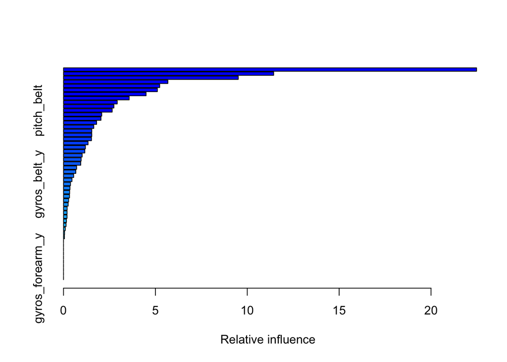

```
## # A tibble: 52 x 2
##    var               rel.inf
##  * <fct>               <dbl>
##  1 roll_belt           22.5
##  2 pitch_forearm       11.4
##  3 yaw_belt             9.51
##  4 magnet_dumbbell_z    5.68
##  5 magnet_dumbbell_y    5.23
##  6 roll_forearm         5.11
##  7 magnet_belt_z        4.49
##  8 accel_forearm_x      3.57
##  9 accel_dumbbell_y     2.92
## 10 gyros_belt_z         2.74
## # ... with 42 more rows
```

```r
tibble::as_tibble(summary(modFit))
```

## Results with Final Test Set

```r
finalPrediction <- predict(modFit, pmltest)
finalPrediction
```

```
##  [1] B A B A A E D B A A B C B A E E A B B B
## Levels: A B C D E
```